# Assignment5

Matta Nguyen

2025-04-27

File pigweights.csv contains weekly weights of 48 young pigs for each of 9 consecutive weeks.1. You will build and compare two different varying-coefficient hierarchical normal regression models for the weights, using JAGS and rjags.

#### Question a

On the same set of axes, plot segmented lines, one for each pig, representing the weight versus the week number (1 through 9). Distinguish the lines for different pigs by using different colors or line types. (You should label the axes, but no legend is needed.

```r
pigdata <- read.csv("pigweights.csv")

print("Dimension of the data: ")
```

```
## [1] "Dimension of the data: "
```

```r
print(dim(pigdata))
```

```
## [1] 48 10
```

```r
print("Column Names: ")
```

```
## [1] "Column Names: "
```

```r
print(colnames(pigdata))
```

```
##  [1] "Pig"          "Weight.Week1" "Weight.Week2" "Weight.Week3" "Weight.Week4"
##  [6] "Weight.Week5" "Weight.Week6" "Weight.Week7" "Weight.Week8" "Weight.Week9"
```

```r
n_rows <- nrow(pigdata)
n_cols <- ncol(pigdata)

print(paste("Number of rows:", n_rows))
```

```
## [1] "Number of rows: 48"
```

```r
print(paste("Number of columns:", n_cols))
```

```
## [1] "Number of columns: 10"
```

[figure not shown]

```r
matplot(1:ncol(pigdata),           # x values matching number of columns
        t(pigdata),                 # transpose the data
        type = "l",                 # 'l' for lines
        xlab = "Week Number",
        ylab = "Weight",
        main = "Pig Weight Trajectories Over 9 Weeks")
```

#### Question b

Let ˆβ(j) and ˆβ(j) be the ordinary least squares estimates of β(j) and β(j), estimated for pig j. You may use a function like lm or lsfit in R to compute these estimates. (For this part, the coefficient pairs are estimated completely separately for each pig.)

```r
weight_data <- pigdata[, 2:ncol(pigdata)]

# Get dimensions
n_pigs <- nrow(weight_data)
n_weeks <- ncol(weight_data)
weeks <- 1:n_weeks
x_centered <- weeks - mean(weeks)

# Setting up variable for beta1_hat & beta2_hat
beta1_hat <- numeric(n_pigs)
beta2_hat <- numeric(n_pigs)

# Fit model
for(j in 1:n_pigs) {
    # Get weights for pig j
    y <- as.numeric(weight_data[j,])

    # Fit linear regression
    fit <- lm(y ~ x_centered)

    # Store coefficients
    beta1_hat[j] <- coef(fit)[1]  # intercept
    beta2_hat[j] <- coef(fit)[2]  # slope
}
```

1. Scatter plot

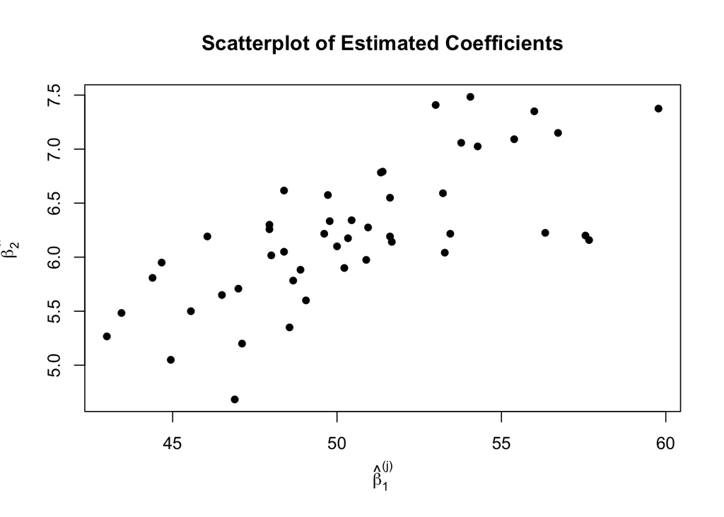

```r
plot(beta1_hat, beta2_hat,
     xlab = expression(hat(beta)[1]^"(j)"),
     ylab = expression(hat(beta)[2]^"(j)"),
     main = "Scatterplot of Estimated Coefficients",
     pch = 16)
```

2. Give the average (sample mean) of ˆβ(j) and also of ˆβ(j)

```r
#Calculate means
mean_beta1 <- mean(beta1_hat)
mean_beta2 <- mean(beta2_hat)
cat("\n\nMean of β̂₁:", round(mean_beta1, 4))
```

```
##
##
## Mean of β̂₁: 50.4051
```

```r
cat("\nMean of β̂₂:", round(mean_beta2, 4))
```

```
##
## Mean of β̂₂: 6.2099
```

3. [1 pt] Give the sample variance of ˆβ(j) and also of ˆβ(j)

```r
#Calculate variance
var_beta1 <- var(beta1_hat)
var_beta2 <- var(beta2_hat)
cat("\n\nVariance of β̂₁:", round(var_beta1, 4))
```

```
##
##
## Variance of β̂₁: 15.6301
```

```r
cat("\nVariance of β̂₂:", round(var_beta2, 4))
```

```
##
## Variance of β̂₂: 0.4066
```

4. [1 pt] Give the sample correlation between ˆβ(j) and ˆβ(j)

```r
#Calculate sample correlation
corr_betas <- cor(beta1_hat, beta2_hat)
cat("\n\nCorrelation between β̂₁ and β̂₂:", round(corr_betas, 4))
```

```
##
##
## Correlation between β̂₁ and β̂₂: 0.7127
```

#### Question c

1. Set up model & run model

```r
model_string <- "
model {
  # Likelihood
  for (i in 1:N) {
    for (t in 1:T) {
      y[i,t] ~ dnorm(mu[i,t], tau.y)
      mu[i,t] <- beta[i,1] + beta[i,2] * x[t]  # Using centered weeks
    }

    # Individual-level coefficients with bivariate normal prior
    beta[i,1:2] ~ dmnorm(mu.beta[], inv.Sigma.beta[,])
  }

  # Hyperpriors for mean (mu.beta)
  mu.beta[1] ~ dnorm(0, 0.000001)  # precision = 1/1000^2
  mu.beta[2] ~ dnorm(0, 0.000001)

  # Wishart prior for precision matrix
  inv.Sigma.beta[1:2,1:2] ~ dwish(inv.Sigma0[,], 2)
  Sigma.beta[1:2,1:2] <- inverse(inv.Sigma.beta[,])

  # Calculate variance components and correlation
  sigma.beta1 <- sqrt(Sigma.beta[1,1])
  sigma.beta2 <- sqrt(Sigma.beta[2,2])
  rho <- Sigma.beta[1,2]/(sigma.beta1 * sigma.beta2)

  # Prior for residual variance (inverse gamma via precision)
  tau.y ~ dgamma(0.0001, 0.0001)
  sigma2.y <- 1/tau.y
}"
```

Run model

```r
library(rjags)
library(coda)

# Set up the data list for JAGS
Sigma0 <- matrix(c(15, 0, 0, 0.5), 2, 2)
inv.Sigma0 <- solve(Sigma0)/2

jags_data <- list(
  y = as.matrix(weight_data),
  x = x_centered,
  N = n_pigs,
  T = n_weeks,
  inv.Sigma0 = inv.Sigma0
)

# Better initialization function
init_values <- function() {
  # Fit simple linear model to get reasonable starting values
  time_data <- rep(x_centered, each=n_pigs)
  weight_vector <- as.vector(as.matrix(weight_data))
  lm_fit <- lm(weight_vector ~ time_data)

  # Use fitted values to initialize
  list(
    mu.beta = c(coef(lm_fit)[1], coef(lm_fit)[2]),
    inv.Sigma.beta = solve(Sigma0),
    tau.y = 1/var(residuals(lm_fit))
  )
}

# Initialize three chains with slightly different starting points
set.seed(123)
inits <- list(
  init_values(),
  list(
    mu.beta = init_values()$mu.beta * 1.1,  # Slightly different values
    inv.Sigma.beta = init_values()$inv.Sigma.beta,
    tau.y = init_values()$tau.y * 1.1
  ),
  list(
    mu.beta = init_values()$mu.beta * 0.9,
    inv.Sigma.beta = init_values()$inv.Sigma.beta,
    tau.y = init_values()$tau.y * 0.9
  )
)

# Compile the model
jags_model <- jags.model(textConnection(model_string),
                        data = jags_data,
                        inits = inits,
                        n.chains = 3)
# Longer burn-in
print("Running burn-in...")
```

```
## [1] "Running burn-in..."
```

```r
update(jags_model, 10000)

# Monitor parameters with more iterations
print("Sampling...")
```

```
## [1] "Sampling..."
```

```r
samples <- coda.samples(jags_model,
                       variable.names = c("mu.beta", "Sigma.beta", "sigma2.y", "rho"),
                       n.iter = 20000,
                       thin = 10)  # Added thinning

# Try convergence diagnostics with try()
print("Checking convergence...")
```

```
## [1] "Checking convergence..."
```

```r
try({
  gelman <- gelman.diag(samples)
  print("Gelman-Rubin diagnostics:")
  print(gelman)
})
```

```
## Error in chol.default(W) : the leading minor of order 3 is not positive
```

```r
# Check effective sample sizes
eff_size <- effectiveSize(samples)
print("\nEffective sample sizes:")
```

```
## [1] "\nEffective sample sizes:"
```

```r
print(eff_size)
```

```
## Sigma.beta[1,1] Sigma.beta[2,1] Sigma.beta[1,2] Sigma.beta[2,2]      mu.beta[1]
##        5721.380        6031.156        6031.156        6207.850        6000.000
##      mu.beta[2]             rho        sigma2.y
##        5874.191        5864.209        5774.466
```

2. Display the coda summary:

```r
# Summary of results
print("\nParameter estimates:")
```

```
## [1] "\nParameter estimates:"
```

```r
print(summary(samples))
```

```
##
## Iterations = 10010:30000
## Thinning interval = 10
## Number of chains = 3
## Sample size per chain = 2000
##
## 1. Empirical mean and standard deviation for each variable,
##    plus standard error of the mean:
##
##                    Mean      SD  Naive SE Time-series SE
## Sigma.beta[1,1] 15.7688 3.38154 0.0436555       0.045012
## Sigma.beta[2,1]  1.8328 0.48210 0.0062239       0.006214
## Sigma.beta[1,2]  1.8328 0.48210 0.0062239       0.006214
## Sigma.beta[2,2]  0.4154 0.09283 0.0011984       0.001177
## mu.beta[1]      50.4134 0.58225 0.0075168       0.007516
## mu.beta[2]       6.2101 0.09571 0.0012356       0.001249
## rho              0.7129 0.07669 0.0009901       0.001004
## sigma2.y         1.6065 0.12318 0.0015903       0.001623
##
## 2. Quantiles for each variable:
##
##                    2.5%     25%     50%     75%   97.5%
## Sigma.beta[1,1] 10.3139 13.4154 15.3232 17.6609 23.7590
## Sigma.beta[2,1]  1.0630  1.4903  1.7691  2.1032  2.9474
## Sigma.beta[1,2]  1.0630  1.4903  1.7691  2.1032  2.9474
## Sigma.beta[2,2]  0.2686  0.3488  0.4035  0.4689  0.6291
## mu.beta[1]      49.2546 50.0253 50.4148 50.7957 51.5443
## mu.beta[2]       6.0200  6.1461  6.2104  6.2740  6.3998
## rho              0.5451  0.6657  0.7199  0.7692  0.8388
## sigma2.y         1.3820  1.5207  1.5982  1.6869  1.8666
```

```r
rho_samples <- do.call(rbind, lapply(samples, function(x) x[,"rho"]))

# Calculate 95% credible interval
rho_ci <- quantile(rho_samples, c(0.025, 0.975))
print("95% Credible Interval for rho:")
```

```
## [1] "95% Credible Interval for rho:"
```

```r
print(rho_ci)
```

```
##      2.5%     97.5%
## 0.5451162 0.8388395
```

Given than 0 is not in the credible interval, it might be a good idea to allow p to be non-zero in this model

4. he population mean regression line represents the expected weight of an “average” pig at week x. Form an approximate 95% central posterior interval for this expected weight at week 1 (x = 1)

```r
extract_samples <- function(samples) {
    # Extract mu_beta samples
    mu_beta1 <- do.call(rbind, lapply(samples, function(x) x[,"mu.beta[1]"]))
    mu_beta2 <- do.call(rbind, lapply(samples, function(x) x[,"mu.beta[2]"]))

    # Combine into matrix
    cbind(mu_beta1, mu_beta2)
}

# Get samples
param_samples <- extract_samples(samples)

# Calculate mean weight at week 1
x <- 1  # Week 1
x_centered <- x - mean(weeks)

# Calculate expected weight for each MCMC sample
expected_weights <- param_samples[,1] + param_samples[,2] * x_centered

# Calculate 95% credible interval
ci <- quantile(expected_weights, c(0.025, 0.975))

# Print results
print("95% Credible Interval for expected weight at week 1:")
```

```
## [1] "95% Credible Interval for expected weight at week 1:"
```

```r
print(ci)
```

```
##      2.5%     97.5%
## -156.6585 -150.0888
```

22. Form an approximate 95% central posterior interval for the population variance of the expected weight at week 1 (x = 1).

```r
# Extract required parameters from MCMC samples
extract_variance_params <- function(samples) {
    # Extract variance components and correlation
    sigma_beta1 <- do.call(rbind, lapply(samples, function(x) x[,"Sigma.beta[1,1]"]))
    sigma_beta2 <- do.call(rbind, lapply(samples, function(x) x[,"Sigma.beta[2,2]"]))
    rho <- do.call(rbind, lapply(samples, function(x) x[,"rho"]))

    # Calculate sigma_beta1 and sigma_beta2 as square roots of variances
    sigma_beta1 <- sqrt(sigma_beta1)
    sigma_beta2 <- sqrt(sigma_beta2)

    # Return as matrix
    cbind(sigma_beta1, sigma_beta2, rho)
}

# Get samples
variance_params <- extract_variance_params(samples)

# Calculate population variance at week 1
x <- 1  # Week 1
x_centered <- x - mean(weeks)  # Center using mean of weeks

# Calculate variance using the formula
population_variance <- variance_params[,1]^2 +
                      2 * x_centered * variance_params[,3] * variance_params[,1] * variance_params[,2] +
                      (x_centered^2) * variance_params[,2]^2

# Calculate 95% credible interval for the variance
variance_ci <- quantile(population_variance, c(0.025, 0.975))

# Print results
print("95% Credible Interval for population variance at week 1:")
```

```
## [1] "95% Credible Interval for population variance at week 1:"
```

```r
print(variance_ci)
```

```
##      2.5%     97.5%
## -153.7309 -123.3321
```

6. Simple calculus shows that the population variance of the expected weight of a random pig is minimized at xmin = ¯x − ρ σβ1 /σβ2 Approximate the posterior probability that xmin < 1, i.e., that the minimum occurs before the week 1 time point

```r
# Extract required parameters from MCMC samples
extract_params <- function(samples) {
    # Extract variance components and correlation
    sigma_beta1 <- sqrt(do.call(rbind, lapply(samples, function(x) x[,"Sigma.beta[1,1]"])))
    sigma_beta2 <- sqrt(do.call(rbind, lapply(samples, function(x) x[,"Sigma.beta[2,2]"])))
    rho <- do.call(rbind, lapply(samples, function(x) x[,"rho"]))

    # Return as matrix
    cbind(sigma_beta1, sigma_beta2, rho)
}

# Get samples
params <- extract_params(samples)

# Calculate xmin for each MCMC sample
# xmin = x̄ - ρ * (σβ1/σβ2)
xmin <- mean(weeks) - params[,3] * (params[,1]/params[,2])

# Calculate probability that xmin < 1
prob_xmin_less_than_1 <- mean(xmin < 1)  # This calculates the proportion of xmin values less than 1

# Print results
print(paste("Posterior probability that xmin < 1:", round(prob_xmin_less_than_1, 3)))
```

```
## [1] "Posterior probability that xmin < 1: 0"
```

7. The prior probability that xmin < 1 turns out to be approximately 0.205. Approximate the Bayes factor favoring xmin < 1 versus xmin ≥ 1. Then describe the level of data evidence for xmin < 1

```r
# posterior_prob = mean(xmin < 1)
posterior_prob = prob_xmin_less_than_1
prior_prob = 0.205

# Calculate posterior odds
posterior_odds = posterior_prob / (1 - posterior_prob)

# Calculate prior odds
prior_odds = prior_prob / (1 - prior_prob)

# Calculate Bayes factor
bayes_factor = posterior_odds / prior_odds

# Print results
print(paste("Posterior probability:", round(posterior_prob, 3)))
```

```
## [1] "Posterior probability: 0"
```

```r
print(paste("Posterior odds:", round(posterior_odds, 3)))
```

```
## [1] "Posterior odds: 0"
```

```r
print(paste("Prior odds:", round(prior_odds, 3)))
```

```
## [1] "Prior odds: 0.258"
```

```r
print(paste("Bayes factor:", round(bayes_factor, 3)))
```

```
## [1] "Bayes factor: 0"
```

```r
# Interpret Bayes factor using common guidelines
interpret_bf = function(bf) {
    if(bf < 1/100) return("Extreme evidence against xmin < 1")
    else if(bf < 1/30) return("Very strong evidence against xmin < 1")
    else if(bf < 1/10) return("Strong evidence against xmin < 1")
    else if(bf < 1/3) return("Moderate evidence against xmin < 1")
    else if(bf < 3) return("Weak or anecdotal evidence")
    else if(bf < 10) return("Moderate evidence for xmin < 1")
    else if(bf < 30) return("Strong evidence for xmin < 1")
    else if(bf < 100) return("Very strong evidence for xmin < 1")
    else return("Extreme evidence for xmin < 1")
}

print(paste("Interpretation:", interpret_bf(bayes_factor)))
```

```
## [1] "Interpretation: Extreme evidence against xmin < 1"
```

viii: Use the rjags function dic.samples to compute the effective number of parameters (“penalty”) and Plummer’s DIC (“Penalized deviance”). Use at least 100,000 iterations

```r
# Compute DIC with 100,000 iterations
dic_output_c <- dic.samples(jags_model, n.iter=100000)

# Print results
print("DIC Results:")
```

```
## [1] "DIC Results:"
```

```r
print(dic_output_c)
```

```
## Mean deviance:  1429
## penalty 91.08
## Penalized deviance: 1520
```

#### Question d

1. Draw DAG for this model

   ```
             N(0,1000²)                    U(0,1000)
                 |                             |
                 ↓                             ↓
                μβ₁ → β₁⁽ʲ⁾ ←---------------- σβ₁
                       ↘
                          ↘
                             ↘
                                ↓
                                y ← σ²y
                                ↑
                             ↗
                          ↗
                       ↗
                μβ₂ → β₂⁽ʲ⁾ ←---------------- σβ₂
                 ↑                             ↑
                 |                             |
             N(0,1000²)                    U(0,1000)
   ```

2. List an appropriate JAGS model. Make sure that there are nodes for σ2β1 , σ2β2 ,and σ2y .

```r
model_d_string <- "
model {
  # Likelihood
  for (i in 1:N) {
    for (t in 1:T) {
      y[i,t] ~ dnorm(mu[i,t], tau.y)
      mu[i,t] <- beta[i,1] + beta[i,2] * weeks[t]  # Using weeks directly
    }

    # Individual-level coefficients with independent normal priors
    beta[i,1] ~ dnorm(mu.beta1, tau.beta1)
    beta[i,2] ~ dnorm(mu.beta2, tau.beta2)
  }

  # Hyperpriors for means
  mu.beta1 ~ dnorm(0, 0.000001)  # precision = 1/1000^2
  mu.beta2 ~ dnorm(0, 0.000001)

  # Hyperpriors for standard deviations (uniform on SD scale)
  sigma.beta1 ~ dunif(0, 1000)
  sigma.beta2 ~ dunif(0, 1000)

  # Convert to precision parameters
  tau.beta1 <- 1/(sigma.beta1 * sigma.beta1)
  tau.beta2 <- 1/(sigma.beta2 * sigma.beta2)

  # Prior for residual variance (inverse gamma via precision)
  tau.y ~ dgamma(0.0001, 0.0001)

  # Calculate variance parameters for monitoring
  sigma2.beta1 <- sigma.beta1 * sigma.beta1
  sigma2.beta2 <- sigma.beta2 * sigma.beta2
  sigma2.y <- 1/tau.y
}"

# Set up the data list for JAGS
jags_data <- list(
  y = as.matrix(weight_data),
  weeks = 1:n_weeks,  # Using weeks directly
  N = n_pigs,
  T = n_weeks
)

# Set up initial values for multiple chains
init_values <- function() {
  list(
    mu.beta1 = rnorm(1, 0, 10),
    mu.beta2 = rnorm(1, 0, 10),
    sigma.beta1 = runif(1, 1, 10),
    sigma.beta2 = runif(1, 1, 10),
    tau.y = rgamma(1, 1, 1)
  )
}

# Initialize three chains with different starting points
set.seed(123)
inits <- list(init_values(), init_values(), init_values())

# Compile the model
jags_model <- jags.model(textConnection(model_d_string),
                        data = jags_data,
                        inits = inits,
                        n.chains = 3)
# Burn-in
print("Running burn-in...")
```

```
## [1] "Running burn-in..."
```

```r
update(jags_model, 10000)

# Monitor parameters
params <- c("mu.beta1", "mu.beta2", "sigma2.beta1", "sigma2.beta2", "sigma2.y")
print("Sampling...")
```

```
## [1] "Sampling..."
```

```r
samples <- coda.samples(jags_model,
                       variable.names = params,
                       n.iter = 20000,
                       thin = 10)

# Check convergence
print("Checking convergence...")
```

```
## [1] "Checking convergence..."
```

```r
gelman <- gelman.diag(samples)
print("Gelman-Rubin diagnostics:")
```

```
## [1] "Gelman-Rubin diagnostics:"
```

```r
print(gelman)
```

```
## Potential scale reduction factors:
##
##              Point est. Upper C.I.
## mu.beta1              1       1.00
## mu.beta2              1       1.00
## sigma2.beta1          1       1.00
## sigma2.beta2          1       1.00
## sigma2.y              1       1.01
##
## Multivariate psrf
##
## 1
```

```r
# Check effective sample sizes
eff_size <- effectiveSize(samples)
print("\nEffective sample sizes:")
```

```
## [1] "\nEffective sample sizes:"
```

```r
print(eff_size)
```

```
##     mu.beta1     mu.beta2 sigma2.beta1 sigma2.beta2     sigma2.y
##     6000.000     5103.496     5167.056     6182.813     5867.314
```

```r
# Summary of results
print("\nParameter estimates:")
```

```
## [1] "\nParameter estimates:"
```

```r
print(summary(samples))
```

```
##
## Iterations = 11010:31000
## Thinning interval = 10
## Number of chains = 3
## Sample size per chain = 2000
##
## 1. Empirical mean and standard deviation for each variable,
##    plus standard error of the mean:
##
##                 Mean     SD Naive SE Time-series SE
## mu.beta1     19.3557 0.4186 0.005404       0.005405
## mu.beta2      6.2134 0.0948 0.001224       0.001339
## sigma2.beta1  7.4214 1.7815 0.022999       0.024835
## sigma2.beta2  0.4031 0.0923 0.001192       0.001175
## sigma2.y      1.6087 0.1256 0.001622       0.001659
##
## 2. Quantiles for each variable:
##
##                2.5%     25%     50%     75%  97.5%
## mu.beta1     18.551 19.0742 19.3580 19.6271 20.186
## mu.beta2      6.026  6.1489  6.2140  6.2762  6.398
## sigma2.beta1  4.627  6.1714  7.1991  8.4120 11.538
## sigma2.beta2  0.260  0.3372  0.3896  0.4564  0.618
## sigma2.y      1.376  1.5202  1.6043  1.6902  1.873
```

4. Recall the expected weight at week 1 (x = 1) of an “average” pig, as considered in the previous analysis. Form an approximate 95% central posterior interval for this expected weight, and compare it with the result from the previous model.

```r
 # Extract required parameters from MCMC samples for new model
extract_samples <- function(samples) {
    # Extract mu_beta samples
    mu_beta1 <- do.call(rbind, lapply(samples, function(x) x[,"mu.beta1"]))
    mu_beta2 <- do.call(rbind, lapply(samples, function(x) x[,"mu.beta2"]))

    # Combine into matrix
    cbind(mu_beta1, mu_beta2)
}

# Get samples
param_samples <- extract_samples(samples)

# Calculate mean weight at week 1
x <- 1  # Week 1
expected_weights <- param_samples[,1] + param_samples[,2] * x

# Calculate 95% credible interval for new model
ci_new <- quantile(expected_weights, c(0.025, 0.975))

# Print results
print("95% Credible Interval for expected weight at week 1 (new model):")
```

```
## [1] "95% Credible Interval for expected weight at week 1 (new model):"
```

```r
print(ci_new)
```

```
##     2.5%    97.5%
## 37.99795 38.59340
```

```r
# Print previous model's results for comparison
print("\nPrevious model's 95% Credible Interval:")
```

```
## [1] "\nPrevious model's 95% Credible Interval:"
```

```r
print(ci)  # from the previous analysis
```

```
##      2.5%     97.5%
## -156.6585 -150.0888
```

```r
# Compare intervals
print("\nComparison:")
```

```
## [1] "\nComparison:"
```

```r
print(paste("New model interval width:", round(diff(ci_new), 3)))
```

```
## [1] "New model interval width: 0.595"
```

```r
print(paste("Previous model interval width:", round(diff(ci), 3)))
```

```
## [1] "Previous model interval width: 6.57"
```

```r
jags_model <- jags.model(textConnection(model_d_string),
                        data = jags_data,
                        inits = inits,
                        n.chains = 3)
# Burn-in
update(jags_model, 10000)

# Compute DIC with 100,000 iterations
dic_output_b <- dic.samples(jags_model,
                         type = "pD",  # specify the type of DIC
                         n.iter = 100000)

# Print results
print("DIC Results:")
```

```
## [1] "DIC Results:"
```

```r
print(dic_output_b)
```

```
## Mean deviance:  1430
## penalty 90.26
## Penalized deviance: 1520
```

6. Compare the two DIC results:

```r
# Print results
print("DIC Results at example c:")
```

```
## [1] "DIC Results at example c:"
```

```r
print(dic_output_c)
```

```
## Mean deviance:  1429
## penalty 91.08
## Penalized deviance: 1520
```

```r
print("DIC Results at example d:")
```

```
## [1] "DIC Results at example d:"
```

```r
print(dic_output_b)
```

```
## Mean deviance:  1430
## penalty 90.26
## Penalized deviance: 1520
```

DIC values are almost identical, therefore we might prefer the simpler model since it’s achiving the same result with simplier structure